# Introduction

> The objective of this notebook is to explore various machine learning model approaches for a 'ham versus spam' classification of SMS text messages. The messages are sourced from a [publicly available dataset on Kaggle](https://www.kaggle.com/uciml/sms-spam-collection-dataset) along with their labels, so I will be creating models in a supervised learning setting.

# Importing Libraries

```python
import pandas as pd
import numpy as np
import string
import re
import textatistic as tstat

import matplotlib.pyplot as plt
import seaborn as sns
sns.set(rc={'figure.figsize':(10,10)})
sns.set(font_scale=1.3)
sns.set_style("whitegrid")

from wordcloud import WordCloud

import scikitplot as skplt

import spacy
from spacy.lang.en.stop_words import STOP_WORDS
from spacy.lang.en import English

from sklearn.preprocessing import LabelEncoder, StandardScaler, MinMaxScaler
from sklearn.model_selection import train_test_split, GridSearchCV, cross_val_score
from sklearn.compose import ColumnTransformer
from sklearn.feature_extraction.text import TfidfVectorizer
from sklearn.linear_model import LogisticRegression
from sklearn.naive_bayes import GaussianNB
from sklearn.svm import SVC
from sklearn.tree import DecisionTreeClassifier
from sklearn.ensemble import RandomForestClassifier, AdaBoostClassifier
from sklearn.neighbors import KNeighborsClassifier
from sklearn.metrics import classification_report, accuracy_score, precision_score, recall_score, roc_auc_score, f1_score

import time

from keras.models import Sequential
from keras.layers import Dense
from keras.utils import to_categorical
```

# Importing Data

> Note: The data uses latin-1 encoding, although it is entirely possible to convert it to unicode for use in Natural Language AutoML.

```python
df = pd.read_csv('spam.csv', encoding = 'latin-1')
df.dropna(how="any", inplace=True, axis=1)
df.columns = ['label', 'text']
df.head(3)
```

|  | label | text |
| --- | --- | --- |
| 0 | ham | Go until jurong point, crazy.. Available only ... |
| 1 | ham | Ok lar... Joking wif u oni... |
| 2 | spam | Free entry in 2 a wkly comp to win FA Cup fina... |

# Feature Engineering

> I start with creating features to better understand the text (i.e. do spam messages tend to have more numbers or capital letters?). Too many features leads to overfitting but for exploratory data analysis, it may be useful.

```python
def feature_engineering(df, target_column):
    # count number of characters in target column (this includes whitespace)
    df['Number of Characters'] = df[target_column].apply(len)

    # count number of words
    df['Number of Words'] = df[target_column].apply(word_count)

    # average word length per target column cell
    df['Average Word Length'] = df[target_column].apply(avg_word_length)

    # calculating the number of capital letters
    df['Number of Capital Letters'] = df[target_column].apply(num_capital_letters)

    # calculating the number of digits
    df['Number of Digits'] = df[target_column].apply(num_digits)

    # calculating the number of punctuations
    df['Number of Punctuation Marks'] = df[target_column].apply(count_punct)

    # calculating the percent of punctuations
    df['Percentage of Punctuation'] = df[target_column].apply(count_punct_percentage)

    # calculating the number of syllables
    df['Number of Syllables'] = df[target_column].apply(syllable_count)

    # calculating the number of polysyllables (words with greater than 3 or more syllables)
    df['Number of Words with Polysyllables'] = df[target_column].apply(polysyllable_count)

# functions to create features
def word_count(string):
    words = string.split()
    return len(words)

def avg_word_length(string):
    words = string.split()
    word_length = [len(word) for word in words]
    avg_word_length = sum(word_length)/len(words)
    return avg_word_length

def num_capital_letters(string):
    return len(re.findall(r'[A-Z]', string))

def num_digits(string):
    return len(re.findall(r'[0-9]', string))

def count_punct(text):
    count = sum([1 for char in text if char in string.punctuation])
    return count

def count_punct_percentage(text):
    count = sum([1 for char in text if char in string.punctuation])
    return round(count/(len(text) - text.count(" ")), 3)*100

def syllable_count(text):
    return tstat.sybl_counts(text)['sybl_count']

def polysyllable_count(text):
    return tstat.sybl_counts(text)['polysyblword_count']
```

```python
feature_engineering(df, 'text')
df.head(3)
```

|  | label | text | Number of Characters | Number of Words | Average Word Length | Number of Capital Letters | Number of Digits | Number of Punctuation Marks | Percentage of Punctuation | Number of Syllables | Number of Words with Polysyllables |
| --- | --- | --- | --- | --- | --- | --- | --- | --- | --- | --- | --- |
| 0 | ham | Go until jurong point, crazy.. Available only ... | 111 | 20 | 4.600000 | 3 | 0 | 9 | 9.8 | 24 | 0 |
| 1 | ham | Ok lar... Joking wif u oni... | 29 | 6 | 4.000000 | 2 | 0 | 6 | 25.0 | 7 | 0 |
| 2 | spam | Free entry in 2 a wkly comp to win FA Cup fina... | 155 | 28 | 4.571429 | 10 | 25 | 6 | 4.7 | 35 | 1 |

# Exploratory Data Analysis (EDA)

```python
# a function to create a wordcloud
def create_wordcloud(df, label):
    wc = WordCloud(background_color = "white", width = 1600, height = 800).generate(' '.join(df['text']))
    plt.imshow(wc)
    plt.axis('off')
    plt.tight_layout(pad=0)
    plt.title(f'Word Cloud for {label} Messages')
    plt.savefig(f'images/Word Cloud for {label} Messages.png', bbox_inches='tight')
    plt.show()

# a function to create a barplot
def create_barplot(df, col):
    title = f'Mean {col}'
    sns.barplot(x = 'label', y = col, data = df).set_title(title)
    plt.savefig(f'images/{title}.png')
    plt.show()

# a function to create a violin (distribution) plot
def create_violinplot(df, col):
    title = f'{col} Distribution'
    sns.violinplot(x = col, y = 'label', data = df, orient = 'h').set_title(title)
    plt.savefig(f'images/{title}.png')
    plt.show()
```

```python
h_mask = (df['label'] == 'ham')
s_mask = (df['label'] == 'spam')
spam = df[s_mask]
ham = df[h_mask]
```

## A look at SMS messages with 'spam' label

```python
spam.describe()
```

|  | Number of Characters | Number of Words | Average Word Length | Number of Capital Letters | Number of Digits | Number of Punctuation Marks | Percentage of Punctuation | Number of Syllables | Number of Words with Polysyllables |
| --- | --- | --- | --- | --- | --- | --- | --- | --- | --- |
| count | 747.000000 | 747.000000 | 747.000000 | 747.000000 | 747.000000 | 747.000000 | 747.000000 | 747.000000 | 747.000000 |
| mean | 138.866131 | 23.851406 | 4.992839 | 15.428380 | 15.759036 | 5.714859 | 4.887818 | 29.183400 | 0.831325 |
| std | 29.183082 | 5.811898 | 1.005943 | 12.306787 | 8.755896 | 3.453301 | 2.769709 | 6.680358 | 0.938274 |
| min | 13.000000 | 2.000000 | 3.333333 | 0.000000 | 0.000000 | 0.000000 | 0.000000 | 2.000000 | 0.000000 |
| 25% | 132.500000 | 22.000000 | 4.423077 | 7.000000 | 10.000000 | 3.000000 | 2.950000 | 27.000000 | 0.000000 |
| 50% | 149.000000 | 25.000000 | 4.884615 | 13.000000 | 16.000000 | 5.000000 | 4.700000 | 31.000000 | 1.000000 |
| 75% | 157.000000 | 28.000000 | 5.375000 | 21.000000 | 22.000000 | 8.000000 | 6.500000 | 34.000000 | 1.000000 |
| max | 224.000000 | 35.000000 | 17.333333 | 128.000000 | 47.000000 | 26.000000 | 20.700000 | 43.000000 | 5.000000 |

## A look at SMS messages with 'ham' label

```python
ham.describe()
```

|  | Number of Characters | Number of Words | Average Word Length | Number of Capital Letters | Number of Digits | Number of Punctuation Marks | Percentage of Punctuation | Number of Syllables | Number of Words with Polysyllables |
| --- | --- | --- | --- | --- | --- | --- | --- | --- | --- |
| count | 4825.000000 | 4825.000000 | 4825.000000 | 4825.000000 | 4825.000000 | 4825.000000 | 4825.000000 | 4825.000000 | 4825.000000 |
| mean | 71.023627 | 14.200622 | 4.177574 | 3.961036 | 0.299275 | 3.974508 | 7.561036 | 16.356269 | 0.356477 |
| std | 58.016023 | 11.424511 | 1.133530 | 10.099676 | 1.063086 | 4.767563 | 7.050755 | 13.186227 | 0.740173 |
| min | 2.000000 | 1.000000 | 1.500000 | 0.000000 | 0.000000 | 0.000000 | 0.000000 | 0.000000 | 0.000000 |
| 25% | 33.000000 | 7.000000 | 3.600000 | 1.000000 | 0.000000 | 1.000000 | 3.400000 | 8.000000 | 0.000000 |
| 50% | 52.000000 | 11.000000 | 4.000000 | 2.000000 | 0.000000 | 3.000000 | 5.800000 | 12.000000 | 0.000000 |
| 75% | 92.000000 | 19.000000 | 4.500000 | 3.000000 | 0.000000 | 5.000000 | 9.900000 | 21.000000 | 1.000000 |
| max | 910.000000 | 171.000000 | 49.000000 | 127.000000 | 23.000000 | 133.000000 | 100.000000 | 201.000000 | 9.000000 |

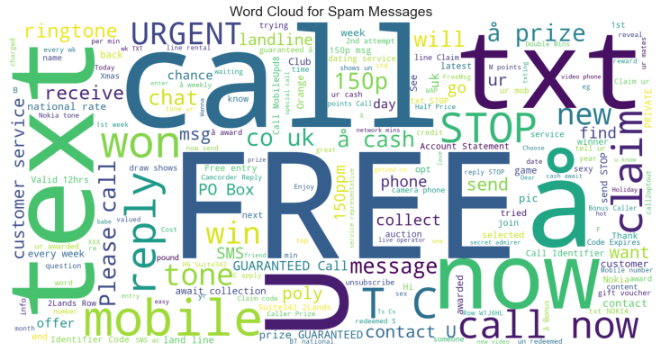

```python
create_wordcloud(spam, 'Spam')
```

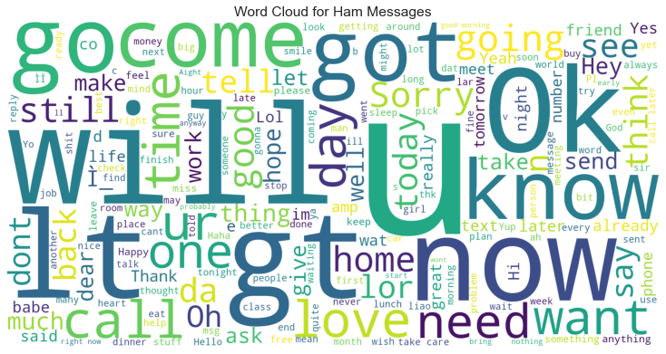

```python
create_wordcloud(ham, 'Ham')
```

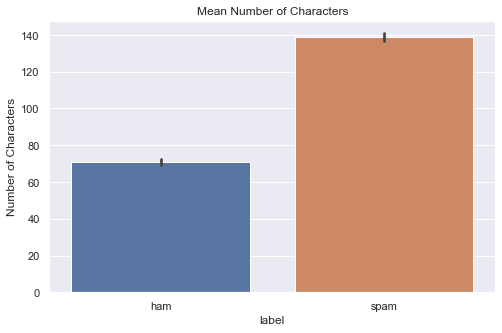

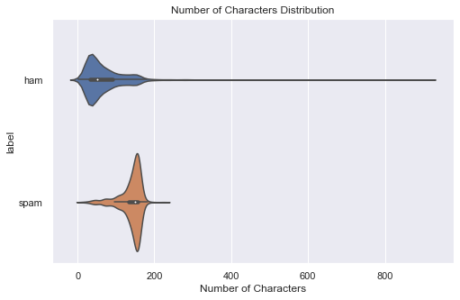

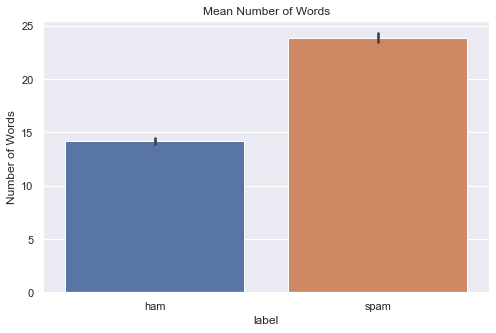

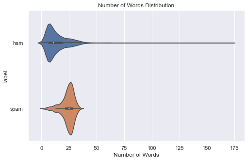

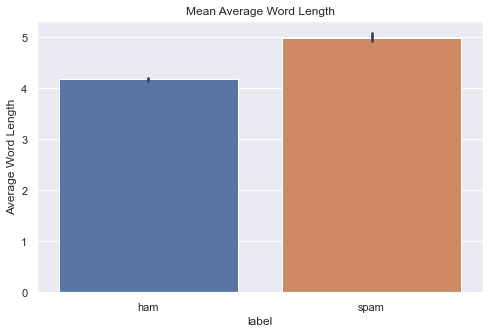

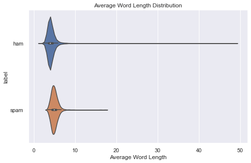

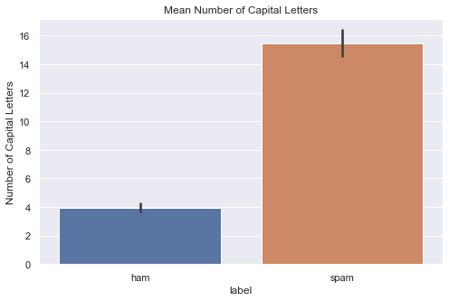

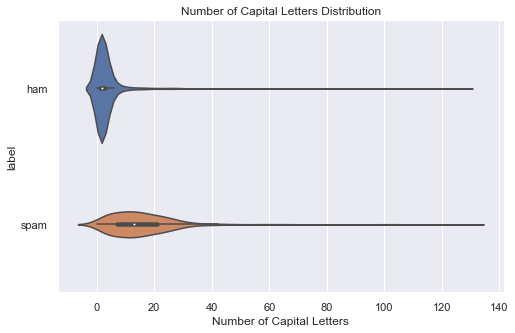

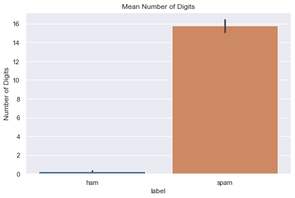

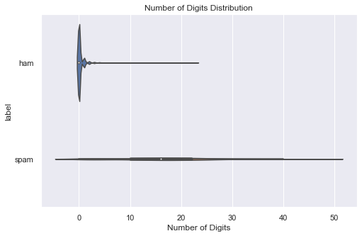

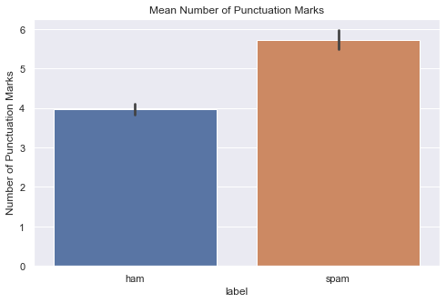

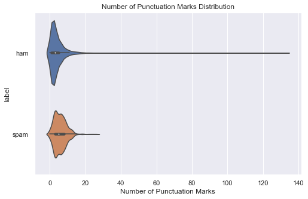

[6 more figures not shown]

```python
sns.set(rc={'figure.figsize':(8,5)})

# filter numerical columns from number of characters onwards
columns = df.columns.tolist()[2:]

for col in columns:
    create_barplot(df, col)
    create_violinplot(df, col)
```

# Preprocessing Data

> Code for preprocessing using SpaCy is referenced from a [DataQuest](https://www.dataquest.io/blog/tutorial-text-classification-in-python-using-spacy/) article. I opted not to use their transformer code and added a list comprehension to process out non-alphabetical tokens.

```python
# create our list of punctuation marks
punctuations = string.punctuation

# load in spaCy model and create a list of stopwords
nlp = spacy.load('en_core_web_sm')
stop_words = spacy.lang.en.stop_words.STOP_WORDS

# load English tokenizer, tagger, parser, NER and word vectors
parser = English()

# Creating our tokenizer function
def spacy_tokenizer(sentence):
    # Creating our token object, which is used to create documents with linguistic annotations.
    mytokens = parser(sentence)

    # Lemmatizing each token and converting each token into lowercase
    mytokens = [word.lemma_.lower().strip() if word.lemma_ != "-PRON-" else word.lower_ for word in mytokens]

    # Removing stop words
    mytokens = [word for word in mytokens if word not in stop_words and word not in punctuations]

    # Removing non-alphabetical tokens
    mytokens = [word for word in mytokens if word.isalpha()]

    # return preprocessed list of tokens
    return mytokens
```

## Splitting Data into Training (70%) and Test (30%) sets

> Some models require dense representations of the data (i.e. with column labels and indices). The default behavior of transforming the data using TF-IDF and standardization means we need to convert that data to a dense representation for specific models (Naive Bayes). This can be done by using the .toarray() or .todense() methods, although if our aim is to understand feature importances in models, another method is needed to restore feature names.

> It should further be noted that StandardScaler from scikit-learn does not store feature names when our extra features are standardized. I have written some messy code to get around this, though I opted not to use it for this project.

```python
le = LabelEncoder()
tfidf_vector = TfidfVectorizer(tokenizer = spacy_tokenizer)

X = df.drop(['label'], axis = 1)
y = le.fit_transform(df.label)
labels = list(le.classes_)
print("The labels are: ", labels)

X_train, X_test, y_train, y_test = train_test_split(X, y, test_size = 0.3, random_state = 42)

# obtaining list of extraneous features
extra_features = X_train.drop(['text'], axis = 1).columns.tolist()

# preprocessing the data through a column transformer, the end result is a Sparse Matrix
ct = ColumnTransformer([('Tfidf Vectorizer', tfidf_vector, 'text'),
                        ('Standardization of Extra Features', StandardScaler(), extra_features)],
                       remainder='passthrough')

# transforming training and test data by vectorizing text column and standardizing extra features
X_train_scaled = ct.fit_transform(X_train)
X_test_scaled = ct.transform(X_test)

# storing train and test data into dense arrays for use in specific models
X_train_scaled_dense = X_train_scaled.todense()
X_test_scaled_dense = X_test_scaled.todense()
```

```
The labels are:  ['ham', 'spam']
```

## An alternative way to keep features for use in feature_importances for models using Pandas DataFrames, indexing, and columns

> I do not use a StandardScaler because it results in some negative values, which can't be used in our Naive Bayes model. Instead I use a MinMaxScaler that transforms our extra features between 0 and 1.

```python
# Uncomment the code below if you require feature names for feature_importances.

# scaler = MinMaxScaler()
# original_index = X_train.index
# X_train_extra_features = scaler.fit_transform(X_train.drop(['text'], axis = 1))
# X_train_extra_features_df = pd.DataFrame(X_train_extra_features, index = original_index, columns = extra_features)

# X_train_tfidf = tfidf_vector.fit_transform(X_train['text'])
# X_train_tfidf_dense = X_train_tfidf.toarray()
# cols = tfidf_vector.get_feature_names()
# X_train_tfidf_dense_df = pd.DataFrame(X_train_tfidf_dense, index = original_index, columns = cols)
# X_train_df = pd.concat([X_train_tfidf_dense_df, X_train_extra_features_df], axis = 1)

# test_indices = X_test.index
# X_test_extra_features = scaler.transform(X_test.drop(['text'], axis = 1))
# X_test_extra_features_df = pd.DataFrame(X_test_extra_features, index = test_indices, columns = extra_features)
# X_test_tfidf_dense = tfidf_vector.transform(X_test['text']).toarray()
# X_test_tfidf_dense_df = pd.DataFrame(X_test_tfidf_dense, index = test_indices, columns = cols)
# X_test_df = pd.concat([X_test_tfidf_dense_df, X_test_extra_features_df], axis = 1)
```

# Modeling

### Helper functions

```python
# a function to print out classification report
def cr(y_test, y_pred, digits = 4):
    print(classification_report(y_test, y_pred, target_names = labels, digits = digits))

# helper function to print out classification report
def best_params(model, params, other = None):
    for key in params.keys():
        print('Best {}: '.format(key), model.best_estimator_.get_params()[key])

def grid_search(model, param_grid):
    # initializing grid
    grid = GridSearchCV(model, param_grid, cv = 5, verbose = 1, n_jobs = -1)

    # training model
    start_time = time.perf_counter()
    best_model = grid.fit(X_train_scaled, y_train)
    end_time = time.perf_counter()
    train_time = (end_time - start_time) * 1000

    # outputting best parameters
    best_params(best_model, param_grid)

    # making predictions
    start_time = time.perf_counter()
    y_pred = best_model.predict(X_test_scaled)
    end_time = time.perf_counter()
    predict_time = (end_time - start_time) * 1000

    # printing out classification report
    cr(y_test, y_pred)

    return best_model, train_time, predict_time
```

## Logistic Regression (Maximum Entropy)

```python
lr_clf = LogisticRegression(max_iter = 3000, warm_start = True, n_jobs = -1)
lr_param_grid = {'C' : np.logspace(-3, 3, 7), 'penalty': ['l1', 'l2', 'elasticnet']}
lr_best_model, lr_train_time, lr_predict_time = grid_search(lr_clf, lr_param_grid)
```

```
Fitting 5 folds for each of 21 candidates, totalling 105 fits
```

```
[Parallel(n_jobs=-1)]: Using backend LokyBackend with 8 concurrent workers.
[Parallel(n_jobs=-1)]: Done  34 tasks      | elapsed:    4.7s
[Parallel(n_jobs=-1)]: Done 105 out of 105 | elapsed:    6.4s finished
```

```
Best C:  1000.0
Best penalty:  l2
              precision    recall  f1-score   support

         ham     0.9898    0.9972    0.9935      1453
        spam     0.9808    0.9315    0.9555       219

    accuracy                         0.9886      1672
   macro avg     0.9853    0.9644    0.9745      1672
weighted avg     0.9886    0.9886    0.9885      1672
```

## Naive Bayes Classifier (GaussianNB)

> Uses dense representation of training and test data.

```python
nb_clf = GaussianNB()

# training model
start_time = time.perf_counter()
nb_clf.fit(X_train_scaled_dense, y_train)
end_time = time.perf_counter()
nb_train_time = (end_time - start_time) * 1000

# predicting on y_test
start_time = time.perf_counter()
y_pred = nb_clf.predict(X_test_scaled_dense)
end_time = time.perf_counter()
nb_predict_time = (end_time - start_time) * 1000

# printing out classification report
cr(y_test, y_pred)
```

```
              precision    recall  f1-score   support

         ham     0.9740    0.8520    0.9090      1453
        spam     0.4638    0.8493    0.6000       219

    accuracy                         0.8517      1672
   macro avg     0.7189    0.8507    0.7545      1672
weighted avg     0.9072    0.8517    0.8685      1672
```

## Support Vector Machine (SVM)

```python
svm_clf = SVC(random_state = 42)
svm_param_grid = {'C': np.logspace(-3, 3, 7), 'gamma' : [0.001, 0.01, 0.1, 1], 'kernel': ['rbf', 'linear']}

svm_best_model, svm_train_time, svm_predict_time = grid_search(svm_clf, svm_param_grid)
```

```
Fitting 5 folds for each of 56 candidates, totalling 280 fits
```

```
[Parallel(n_jobs=-1)]: Using backend LokyBackend with 8 concurrent workers.
[Parallel(n_jobs=-1)]: Done  34 tasks      | elapsed:    2.2s
[Parallel(n_jobs=-1)]: Done 184 tasks      | elapsed:   10.6s
[Parallel(n_jobs=-1)]: Done 280 out of 280 | elapsed:   17.6s finished
```

```
Best C:  1000.0
Best gamma:  0.001
Best kernel:  rbf
              precision    recall  f1-score   support

         ham     0.9918    0.9966    0.9942      1453
        spam     0.9764    0.9452    0.9606       219

    accuracy                         0.9898      1672
   macro avg     0.9841    0.9709    0.9774      1672
weighted avg     0.9898    0.9898    0.9898      1672
```

## Decision Trees

```python
tree_clf = DecisionTreeClassifier(max_depth = 2, random_state = 42)
tree_param_grid = {'criterion': ['gini', 'entropy'],
             'min_samples_split' : np.arange(10, 500, 20)}
tree_best_model, tree_train_time, tree_predict_time = grid_search(tree_clf, tree_param_grid)
```

```
Fitting 5 folds for each of 50 candidates, totalling 250 fits
```

```
[Parallel(n_jobs=-1)]: Using backend LokyBackend with 8 concurrent workers.
[Parallel(n_jobs=-1)]: Done  56 tasks      | elapsed:    0.4s
```

```
Best criterion:  entropy
Best min_samples_split:  10
              precision    recall  f1-score   support

         ham     0.9857    0.9938    0.9897      1453
        spam     0.9565    0.9041    0.9296       219

    accuracy                         0.9821      1672
   macro avg     0.9711    0.9490    0.9596      1672
weighted avg     0.9818    0.9821    0.9818      1672
```

[output not shown]

## Random Forests

```python
rf_clf = RandomForestClassifier(n_jobs = -1, random_state = 42,
                                 warm_start = True)
rf_param_grid = {'criterion': ['gini', 'entropy'],
             'n_estimators': np.arange(0, 500, 25)}
rf_best_model, rf_train_time, rf_predict_time = grid_search(rf_clf, rf_param_grid)
```

```
[Parallel(n_jobs=-1)]: Using backend LokyBackend with 8 concurrent workers.
```

```
Fitting 5 folds for each of 40 candidates, totalling 200 fits
```

```
[Parallel(n_jobs=-1)]: Done  50 tasks      | elapsed:   18.1s
[Parallel(n_jobs=-1)]: Done 200 out of 200 | elapsed:  2.0min finished
```

```
Best criterion:  entropy
Best n_estimators:  275
              precision    recall  f1-score   support

         ham     0.9851    1.0000    0.9925      1453
        spam     1.0000    0.8995    0.9471       219

    accuracy                         0.9868      1672
   macro avg     0.9925    0.9498    0.9698      1672
weighted avg     0.9870    0.9868    0.9865      1672
```

## AdaBoost

```python
ada_clf = AdaBoostClassifier(n_estimators=100, random_state = 42)
ada_param_grid = {'n_estimators': np.arange(0, 500, 25), 'learning_rate' : [0.001, 0.01, 0.1]}
ada_best_model, ada_train_time, ada_predict_time = grid_search(ada_clf, ada_param_grid)
```

```
Fitting 5 folds for each of 60 candidates, totalling 300 fits
```

```
[Parallel(n_jobs=-1)]: Using backend LokyBackend with 8 concurrent workers.
[Parallel(n_jobs=-1)]: Done  49 tasks      | elapsed:   25.4s
[Parallel(n_jobs=-1)]: Done 200 tasks      | elapsed:  3.0min
[Parallel(n_jobs=-1)]: Done 300 out of 300 | elapsed:  4.7min finished
```

```
Best n_estimators:  475
Best learning_rate:  0.1
              precision    recall  f1-score   support

         ham     0.9918    0.9986    0.9952      1453
        spam     0.9904    0.9452    0.9673       219

    accuracy                         0.9916      1672
   macro avg     0.9911    0.9719    0.9812      1672
weighted avg     0.9916    0.9916    0.9915      1672
```

## K-Nearest Neighbors

```python
knn_clf = KNeighborsClassifier(n_jobs = -1)
knn_param_grid = {'n_neighbors': np.arange(5, 105, 5),
             'weights' : ['uniform', 'distance']}
knn_best_model, knn_train_time, knn_predict_time = grid_search(knn_clf, knn_param_grid)
```

```
Fitting 5 folds for each of 40 candidates, totalling 200 fits
```

```
[Parallel(n_jobs=-1)]: Using backend LokyBackend with 8 concurrent workers.
[Parallel(n_jobs=-1)]: Done  34 tasks      | elapsed:    1.6s
[Parallel(n_jobs=-1)]: Done 184 tasks      | elapsed:    7.9s
[Parallel(n_jobs=-1)]: Done 200 out of 200 | elapsed:    8.5s finished
```

```
Best n_neighbors:  10
Best weights:  distance
              precision    recall  f1-score   support

         ham     0.9857    0.9986    0.9921      1453
        spam     0.9900    0.9041    0.9451       219

    accuracy                         0.9862      1672
   macro avg     0.9879    0.9514    0.9686      1672
weighted avg     0.9863    0.9862    0.9860      1672
```

## Neural Networks

```python
n_cols = X_train_scaled.shape[1]

nn_model = Sequential()
nn_model.add(Dense(50, activation = 'relu', input_shape = (n_cols, )))
nn_model.add(Dense(1, activation = 'sigmoid'))
nn_model.compile(optimizer = 'adam', loss = 'binary_crossentropy',
              metrics = ['accuracy'])

start_time = time.perf_counter()
history = nn_model.fit(X_train_scaled, y_train, validation_data = (X_test_scaled, y_test), epochs = 12, verbose = 0)
end_time = time.perf_counter()
nn_train_time = (end_time - start_time) * 1000

start_time = time.perf_counter()
y_pred = nn_model.predict_classes(X_test_scaled)
end_time = time.perf_counter()
nn_predict_time = (end_time - start_time) * 1000

cr(y_test, y_pred)
```

```
              precision    recall  f1-score   support

         ham     0.9911    0.9993    0.9952      1453
        spam     0.9952    0.9406    0.9671       219

    accuracy                         0.9916      1672
   macro avg     0.9931    0.9700    0.9812      1672
weighted avg     0.9917    0.9916    0.9915      1672
```

# Interpreting Results

> In this section, I visualize the training and prediction times. Additional metrics are provided such as accuracy, precision, recall, and F-scores (on the test data).

### Helper Method

```python
# a function to create barplots for each model
sns.set(rc={'figure.figsize':(7,7)})
def create_model_barplot(data, col1, col2, title, lim):
    g = sns.barplot(data.iloc[:, col2], data.iloc[:, col1])
    ax = g
    for p in ax.patches:
        ax.annotate("%.2f" % p.get_height(), (p.get_x() + p.get_width() / 2., p.get_height()),
                    ha='center', va='center', color='gray', xytext=(0, 20),
                    textcoords='offset points')
    g.set_ylim(0, lim)
    plt.xticks(rotation=45)
    plt.title(title)
    plt.savefig(f'images/{title}.png', bbox_inches = "tight")
    plt.show()
```

## Aggregating Results

> I aggregate the results as lists for use in a for loop.

```python
model_names = ['Logistic Regression', 'Naive Bayes Classifier', 'SVM', 'Decision Tree',
               'Random Forest', 'AdaBoost', 'KNN', 'Neural Network']

models = [lr_best_model, nb_clf, svm_best_model, tree_best_model,
          rf_best_model, ada_best_model, knn_best_model, nn_model]

training_times = [lr_train_time, nb_train_time, svm_train_time, tree_train_time,
                  rf_train_time, ada_train_time, knn_train_time, nn_train_time]

predict_times = [lr_predict_time, nb_predict_time, svm_predict_time, tree_predict_time,
                  rf_predict_time, ada_predict_time, knn_predict_time, nn_predict_time]

accuracy_scores = []
precision_scores = []
recall_scores = []
f1_scores = []
```

## Visualizing Results

### Confusion Matrices

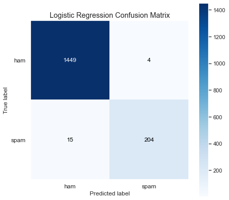

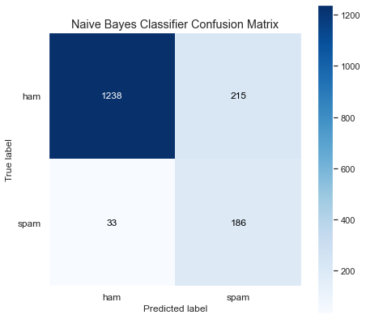

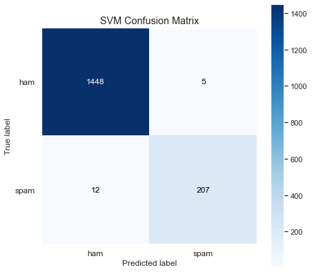

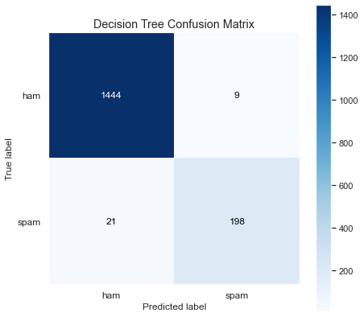

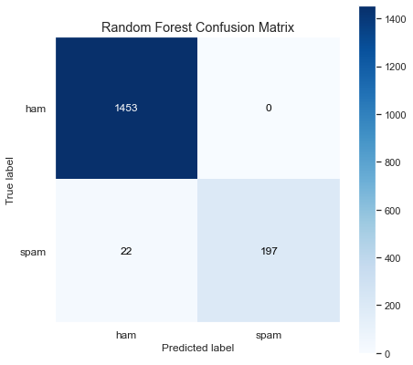

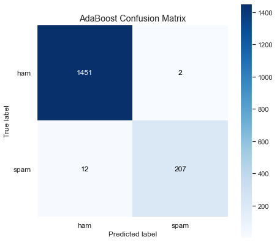

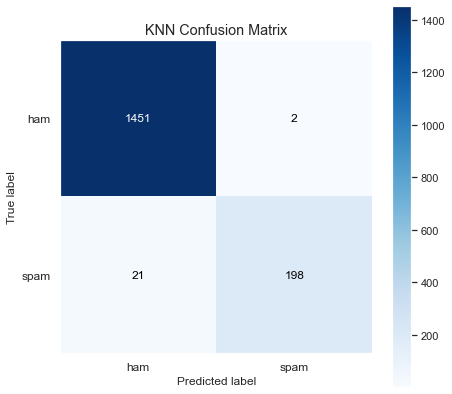

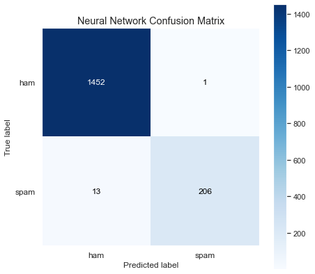

```python
# plotting confusion matrices for each model
count = 0
for model in models:
    title = f"{model_names[count]} Confusion Matrix"
    if model == nb_clf:
        y_pred = nb_clf.predict(X_test_scaled_dense)
    elif model == nn_model:
        y_pred = model.predict_classes(X_test_scaled)
    else:
        y_pred = model.predict(X_test_scaled)
    ax = skplt.metrics.plot_confusion_matrix(y_test, y_pred, title = title, cmap = plt.cm.Blues)
    ax.xaxis.set_ticklabels(['ham', 'spam']); ax.yaxis.set_ticklabels(['ham', 'spam'])
    count += 1
    plt.savefig(f'images/{title}.png', bbox_inches='tight')
    plt.show()

    # calculating these lists for later use
    accuracy_scores.append(accuracy_score(y_test, y_pred))
    precision_scores.append(precision_score(y_test, y_pred))
    recall_scores.append(recall_score(y_test, y_pred))
    f1_scores.append(f1_score(y_test, y_pred))
```

### Tabularized Results

```python
# training time is technically in milliseconds, so it needs to be converted to seconds. This can be confusing.
data = {'Model Name': model_names, 'Training Time (seconds)': training_times, 'Prediction Time (ms)': predict_times,
        'Accuracy': accuracy_scores, 'Precision': precision_scores, 'Recall': recall_scores,
        'F1 Score': f1_scores}
results_df = pd.DataFrame(data)

# converting this column to seconds rather than the milliseconds measurement
results_df['Training Time (seconds)'] = results_df['Training Time (seconds)']/1000.0
results_df
```

|  | Model Name | Training Time (seconds) | Prediction Time (ms) | Accuracy | Precision | Recall | F1 Score |
| --- | --- | --- | --- | --- | --- | --- | --- |
| 0 | Logistic Regression | 6.816989 | 0.2880 | 0.988636 | 0.980769 | 0.931507 | 0.955504 |
| 1 | Naive Bayes Classifier | 0.502790 | 284.1727 | 0.851675 | 0.463840 | 0.849315 | 0.600000 |
| 2 | SVM | 17.950938 | 68.0803 | 0.989833 | 0.976415 | 0.945205 | 0.960557 |
| 3 | Decision Tree | 1.476393 | 0.3699 | 0.982057 | 0.956522 | 0.904110 | 0.929577 |
| 4 | Random Forest | 120.142929 | 114.4811 | 0.986842 | 1.000000 | 0.899543 | 0.947115 |
| 5 | AdaBoost | 283.519744 | 211.1574 | 0.991627 | 0.990431 | 0.945205 | 0.967290 |
| 6 | KNN | 8.598907 | 259.2407 | 0.986244 | 0.990000 | 0.904110 | 0.945107 |
| 7 | Neural Network | 8.071138 | 87.5571 | 0.991627 | 0.995169 | 0.940639 | 0.967136 |

### Visualizing Results from Table

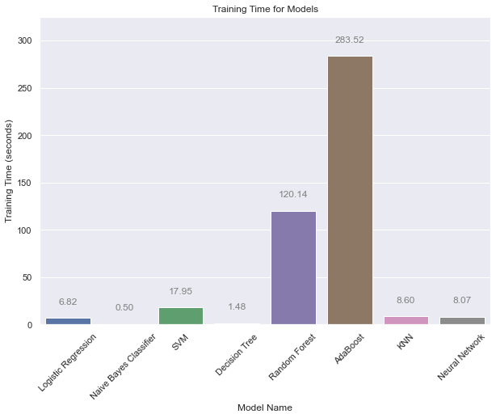

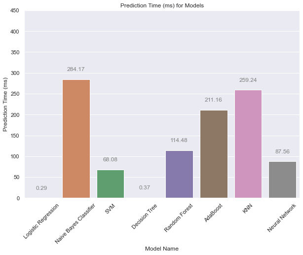

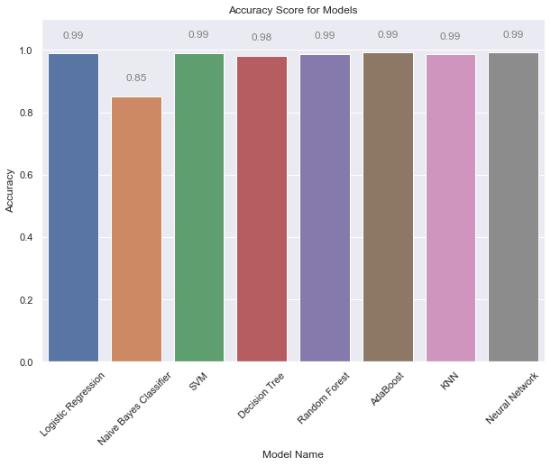

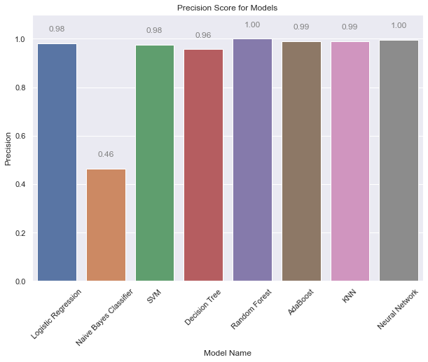

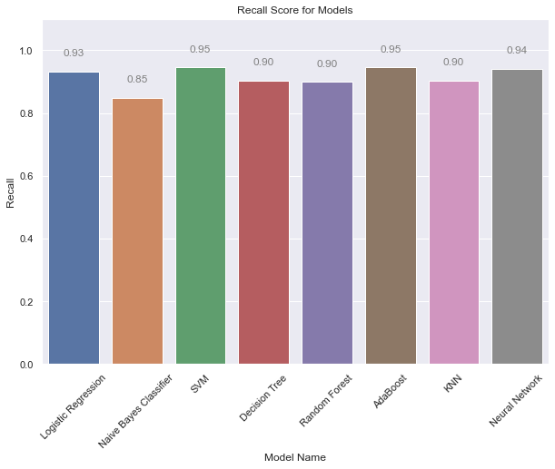

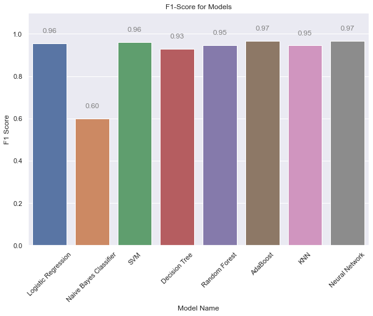

```python
sns.set(rc={'figure.figsize':(10,7)})
create_model_barplot(results_df, 1, 0, 'Training Time for Models', 325)
create_model_barplot(results_df, 2, 0, 'Prediction Time (ms) for Models', 450)
create_model_barplot(results_df, 3, 0, 'Accuracy Score for Models', 1.1)
create_model_barplot(results_df, 4, 0, 'Precision Score for Models', 1.1)
create_model_barplot(results_df, 5, 0, 'Recall Score for Models', 1.1)
create_model_barplot(results_df, 6, 0, 'F1-Score for Models', 1.1)
```

# Conclusions

> The training times for the models vary depending on how many parameters were searched for during our exhaustive Gridsearch. Under the cells for each model, we can find a print out of the number of fits required by each model.

> The prediction times are a more consistent metric and is measured in milliseconds because of how fast it is. It is notable that if we are going for fast prediction times, we may opt for a Logistic Regression model or a Decision Tree Model. There is an argument to be made for trying other models based on the metrics they've achieved on the test data (30% of data that we held out).

> Precision, Recall, and F-scores are the most imperative metrics for determining how good each model is. These metrics all range from 0 to 1 and mean different things. Precision is how good our model is at predicting the positive class. A high precision means that our models won't mistake ham labels as spam. If our training data consisted of emails, we know that if a user does not get their email, it is likely to be found in the spam pile. As modelers, we want to avoid a user losing out on their emails. The same logic could then apply to SMS messages if there were a spam folder.

> Building off the email example, a high recall would mean a user is unlikely to see spam in their inbox. It is how good we are at predicting spam. But what if we want a model that gives us the best of both worlds?

> If our goal is to find a balance between precision and recall, then we want to focus on the harmonic mean between precision and recall. This is known as F-score and luckily it is easy to interpret for a binary classification task.

> To continue with our conclusions, both Random Forests and Neural Networks seem to yield the best precision scores. AdaBoost and support vector machines give us a high recall. If we want to focus on both metrics, AdaBoost and Neural Networks seem to have the most promise.

> Future directions for research may be additional data preprocessing steps (i.e. bag of words models, lexical normalization), using pre-trained word embeddings such as Word2Vec and GloVe, and utilizing different neural network architectures such as convolutional, recurrent, and hierarchical neural networks.